# R Notebook

```r
library(tidyverse)
library(janitor)
library(lubridate)
library(modelr)
library(pROC)
library(glmulti)
library(fastDummies)
```

| datetime | humidity | pressure | temperature |
| --- | --- | --- | --- |
| 2017-01-01 00:00:00 | 44 | 1014 | 5.610 |
| 2017-01-01 01:00:00 | 48 | 1014 | 5.540 |
| 2017-01-01 02:00:00 | 48 | 1013 | 5.770 |
| 2017-01-01 03:00:00 | 48 | 1013 | 5.500 |
| 2017-01-01 04:00:00 | 45 | 1013 | 5.690 |
| 2017-01-01 05:00:00 | 45 | 1013 | 5.920 |
| 2017-01-01 06:00:00 | 45 | 1013 | 5.990 |
| 2017-01-01 07:00:00 | 45 | 1012 | 6.060 |
| 2017-01-01 08:00:00 | 45 | 1013 | 6.280 |
| 2017-01-01 09:00:00 | 42 | 1014 | 6.350 |

[output cut: 990 more lines]

# Model 1 - Simple Weather Model

1. weather only
2. weather and time
3. weather, time and carrier/plane

| wday | month | hour | carrier | is_delayed | plane_age | engine | size_cat | wind_speed | visib | min_wind_dev | wind_magnitude | humidity | pressure | temperature | prcp | snow | snow_depth | has_weather_warning |
| --- | --- | --- | --- | --- | --- | --- | --- | --- | --- | --- | --- | --- | --- | --- | --- | --- | --- | --- |
| Sun | 1 | 8 | B6 | FALSE | 7 | Turbo-fan | small | 17.26170 | 10.0 | 20 | 345.2340 | 45 | 1013 | 6.28 | 0.000 | 0 | 0 | FALSE |
| Sun | 1 | 8 | EV | FALSE | 17 | Turbo-fan | small | 17.26170 | 10.0 | 20 | 345.2340 | 45 | 1013 | 6.28 | 0.000 | 0 | 0 | FALSE |
| Sun | 1 | 8 | UA | FALSE | 27 | Turbo-fan | medium | 17.26170 | 10.0 | 20 | 345.2340 | 45 | 1013 | 6.28 | 0.000 | 0 | 0 | FALSE |
| Sun | 1 | 8 | EV | FALSE | 15 | Turbo-fan | small | 17.26170 | 10.0 | 20 | 345.2340 | 45 | 1013 | 6.28 | 0.000 | 0 | 0 | FALSE |
| Sun | 1 | 8 | UA | FALSE | 17 | Turbo-fan | medium | 17.26170 | 10.0 | 20 | 345.2340 | 45 | 1013 | 6.28 | 0.000 | 0 | 0 | FALSE |
| Sun | 1 | 8 | EV | FALSE | 15 | Turbo-fan | small | 17.26170 | 10.0 | 20 | 345.2340 | 45 | 1013 | 6.28 | 0.000 | 0 | 0 | FALSE |
| Sun | 1 | 8 | DL | FALSE | 26 | Turbo-fan | medium | 17.26170 | 10.0 | 20 | 345.2340 | 45 | 1013 | 6.28 | 0.000 | 0 | 0 | FALSE |
| Sun | 1 | 8 | UA | FALSE | 22 | Turbo-fan | medium | 17.26170 | 10.0 | 20 | 345.2340 | 45 | 1013 | 6.28 | 0.000 | 0 | 0 | FALSE |
| Sun | 1 | 8 | UA | FALSE | 22 | Turbo-fan | large | 17.26170 | 10.0 | 20 | 345.2340 | 45 | 1013 | 6.28 | 0.000 | 0 | 0 | FALSE |
| Sun | 1 | 8 | B6 | FALSE | 10 | Turbo-fan | small | 17.26170 | 10.0 | 20 | 345.2340 | 45 | 1013 | 6.28 | 0.000 | 0 | 0 | FALSE |

[output cut: 990 more lines]

## create test/train split

```r
n_data <- nrow(model1_base_data)
test_index <- sample(1:n_data, size = n_data * 0.2)

test  <- slice(model1_base_data, test_index)
train <- slice(model1_base_data, -test_index)

train
```

| wday | month | hour | carrier | is_delayed | plane_age | engine | size_cat | wind_speed | visib | min_wind_dev | wind_magnitude | humidity | pressure | temperature | prcp | snow | snow_depth | has_weather_warning |
| --- | --- | --- | --- | --- | --- | --- | --- | --- | --- | --- | --- | --- | --- | --- | --- | --- | --- | --- |
| Sun | 1 | 8 | B6 | FALSE | 7 | Turbo-fan | small | 17.26170 | 10.0 | 20 | 345.2340 | 45 | 1013 | 6.28 | 0.000 | 0 | 0 | FALSE |
| Sun | 1 | 8 | EV | FALSE | 17 | Turbo-fan | small | 17.26170 | 10.0 | 20 | 345.2340 | 45 | 1013 | 6.28 | 0.000 | 0 | 0 | FALSE |
| Sun | 1 | 8 | UA | FALSE | 27 | Turbo-fan | medium | 17.26170 | 10.0 | 20 | 345.2340 | 45 | 1013 | 6.28 | 0.000 | 0 | 0 | FALSE |
| Sun | 1 | 8 | EV | FALSE | 15 | Turbo-fan | small | 17.26170 | 10.0 | 20 | 345.2340 | 45 | 1013 | 6.28 | 0.000 | 0 | 0 | FALSE |
| Sun | 1 | 8 | EV | FALSE | 15 | Turbo-fan | small | 17.26170 | 10.0 | 20 | 345.2340 | 45 | 1013 | 6.28 | 0.000 | 0 | 0 | FALSE |
| Sun | 1 | 8 | DL | FALSE | 26 | Turbo-fan | medium | 17.26170 | 10.0 | 20 | 345.2340 | 45 | 1013 | 6.28 | 0.000 | 0 | 0 | FALSE |
| Sun | 1 | 8 | UA | FALSE | 22 | Turbo-fan | medium | 17.26170 | 10.0 | 20 | 345.2340 | 45 | 1013 | 6.28 | 0.000 | 0 | 0 | FALSE |
| Sun | 1 | 8 | B6 | FALSE | 10 | Turbo-fan | small | 17.26170 | 10.0 | 20 | 345.2340 | 45 | 1013 | 6.28 | 0.000 | 0 | 0 | FALSE |
| Sun | 1 | 8 | EV | FALSE | 15 | Turbo-fan | small | 17.26170 | 10.0 | 20 | 345.2340 | 45 | 1013 | 6.28 | 0.000 | 0 | 0 | FALSE |
| Sun | 1 | 8 | UA | TRUE | 17 | Turbo-fan | large | 17.26170 | 10.0 | 20 | 345.2340 | 45 | 1013 | 6.28 | 0.000 | 0 | 0 | FALSE |

[output cut: 990 more lines]

```r
NA
```

```r
# Model 1a - weather only and is_delayed flag
model1a_data <- train %>%
  select(wind_speed:has_weather_warning, is_delayed)

model1a_data
```

| wind_speed | visib | min_wind_dev | wind_magnitude | humidity | pressure | temperature | prcp | snow | snow_depth | has_weather_warning | is_delayed |
| --- | --- | --- | --- | --- | --- | --- | --- | --- | --- | --- | --- |
| 17.26170 | 10.0 | 20 | 345.2340 | 45 | 1013 | 6.28 | 0.000 | 0 | 0 | FALSE | FALSE |
| 17.26170 | 10.0 | 20 | 345.2340 | 45 | 1013 | 6.28 | 0.000 | 0 | 0 | FALSE | FALSE |
| 17.26170 | 10.0 | 20 | 345.2340 | 45 | 1013 | 6.28 | 0.000 | 0 | 0 | FALSE | FALSE |
| 17.26170 | 10.0 | 20 | 345.2340 | 45 | 1013 | 6.28 | 0.000 | 0 | 0 | FALSE | FALSE |
| 17.26170 | 10.0 | 20 | 345.2340 | 45 | 1013 | 6.28 | 0.000 | 0 | 0 | FALSE | FALSE |
| 17.26170 | 10.0 | 20 | 345.2340 | 45 | 1013 | 6.28 | 0.000 | 0 | 0 | FALSE | FALSE |
| 17.26170 | 10.0 | 20 | 345.2340 | 45 | 1013 | 6.28 | 0.000 | 0 | 0 | FALSE | FALSE |
| 17.26170 | 10.0 | 20 | 345.2340 | 45 | 1013 | 6.28 | 0.000 | 0 | 0 | FALSE | FALSE |
| 17.26170 | 10.0 | 20 | 345.2340 | 45 | 1013 | 6.28 | 0.000 | 0 | 0 | FALSE | FALSE |
| 17.26170 | 10.0 | 20 | 345.2340 | 45 | 1013 | 6.28 | 0.000 | 0 | 0 | FALSE | TRUE |

[output cut: 990 more lines]

```r
# Model 1b - weather and time data
model1b_data <- train %>%
  select(wday:hour, wind_speed:has_weather_warning, is_delayed)

model1b_data
```

| wday | month | hour | wind_speed | visib | min_wind_dev | wind_magnitude | humidity | pressure | temperature | prcp | snow | snow_depth | has_weather_warning | is_delayed |
| --- | --- | --- | --- | --- | --- | --- | --- | --- | --- | --- | --- | --- | --- | --- |
| Sun | 1 | 8 | 17.26170 | 10.0 | 20 | 345.2340 | 45 | 1013 | 6.28 | 0.000 | 0 | 0 | FALSE | FALSE |
| Sun | 1 | 8 | 17.26170 | 10.0 | 20 | 345.2340 | 45 | 1013 | 6.28 | 0.000 | 0 | 0 | FALSE | FALSE |
| Sun | 1 | 8 | 17.26170 | 10.0 | 20 | 345.2340 | 45 | 1013 | 6.28 | 0.000 | 0 | 0 | FALSE | FALSE |
| Sun | 1 | 8 | 17.26170 | 10.0 | 20 | 345.2340 | 45 | 1013 | 6.28 | 0.000 | 0 | 0 | FALSE | FALSE |
| Sun | 1 | 8 | 17.26170 | 10.0 | 20 | 345.2340 | 45 | 1013 | 6.28 | 0.000 | 0 | 0 | FALSE | FALSE |
| Sun | 1 | 8 | 17.26170 | 10.0 | 20 | 345.2340 | 45 | 1013 | 6.28 | 0.000 | 0 | 0 | FALSE | FALSE |
| Sun | 1 | 8 | 17.26170 | 10.0 | 20 | 345.2340 | 45 | 1013 | 6.28 | 0.000 | 0 | 0 | FALSE | FALSE |
| Sun | 1 | 8 | 17.26170 | 10.0 | 20 | 345.2340 | 45 | 1013 | 6.28 | 0.000 | 0 | 0 | FALSE | FALSE |
| Sun | 1 | 8 | 17.26170 | 10.0 | 20 | 345.2340 | 45 | 1013 | 6.28 | 0.000 | 0 | 0 | FALSE | FALSE |
| Sun | 1 | 8 | 17.26170 | 10.0 | 20 | 345.2340 | 45 | 1013 | 6.28 | 0.000 | 0 | 0 | FALSE | TRUE |

[output cut: 990 more lines]

```r
# Model 1c - weather, time and plane/carrier data
model1c_data <- train

model1c_data
```

| wday | month | hour | carrier | is_delayed | plane_age | engine | size_cat | wind_speed | visib | min_wind_dev | wind_magnitude | humidity | pressure | temperature | prcp | snow | snow_depth | has_weather_warning |
| --- | --- | --- | --- | --- | --- | --- | --- | --- | --- | --- | --- | --- | --- | --- | --- | --- | --- | --- |
| Sun | 1 | 8 | B6 | FALSE | 7 | Turbo-fan | small | 17.26170 | 10.0 | 20 | 345.2340 | 45 | 1013 | 6.28 | 0.000 | 0 | 0 | FALSE |
| Sun | 1 | 8 | EV | FALSE | 17 | Turbo-fan | small | 17.26170 | 10.0 | 20 | 345.2340 | 45 | 1013 | 6.28 | 0.000 | 0 | 0 | FALSE |
| Sun | 1 | 8 | UA | FALSE | 27 | Turbo-fan | medium | 17.26170 | 10.0 | 20 | 345.2340 | 45 | 1013 | 6.28 | 0.000 | 0 | 0 | FALSE |
| Sun | 1 | 8 | EV | FALSE | 15 | Turbo-fan | small | 17.26170 | 10.0 | 20 | 345.2340 | 45 | 1013 | 6.28 | 0.000 | 0 | 0 | FALSE |
| Sun | 1 | 8 | EV | FALSE | 15 | Turbo-fan | small | 17.26170 | 10.0 | 20 | 345.2340 | 45 | 1013 | 6.28 | 0.000 | 0 | 0 | FALSE |
| Sun | 1 | 8 | DL | FALSE | 26 | Turbo-fan | medium | 17.26170 | 10.0 | 20 | 345.2340 | 45 | 1013 | 6.28 | 0.000 | 0 | 0 | FALSE |
| Sun | 1 | 8 | UA | FALSE | 22 | Turbo-fan | medium | 17.26170 | 10.0 | 20 | 345.2340 | 45 | 1013 | 6.28 | 0.000 | 0 | 0 | FALSE |
| Sun | 1 | 8 | B6 | FALSE | 10 | Turbo-fan | small | 17.26170 | 10.0 | 20 | 345.2340 | 45 | 1013 | 6.28 | 0.000 | 0 | 0 | FALSE |
| Sun | 1 | 8 | EV | FALSE | 15 | Turbo-fan | small | 17.26170 | 10.0 | 20 | 345.2340 | 45 | 1013 | 6.28 | 0.000 | 0 | 0 | FALSE |
| Sun | 1 | 8 | UA | TRUE | 17 | Turbo-fan | large | 17.26170 | 10.0 | 20 | 345.2340 | 45 | 1013 | 6.28 | 0.000 | 0 | 0 | FALSE |

[output cut: 990 more lines]

```r
NA
```

```r
model1a <- glm(is_delayed ~ .,
              data = model1a_data,
              family = binomial(link = "logit"))

summary(model1a)
```

```
Call:
glm(formula = is_delayed ~ ., family = binomial(link = "logit"),
    data = model1a_data)

Deviance Residuals:
    Min       1Q   Median       3Q      Max
-1.9217  -0.7799  -0.6287  -0.2841   2.5418

Coefficients:
                          Estimate Std. Error z value Pr(>|z|)
(Intercept)             23.5638720  1.4452677  16.304  < 2e-16 ***
wind_speed               0.0232398  0.0042903   5.417 6.07e-08 ***
visib                   -0.0874355  0.0050829 -17.202  < 2e-16 ***
min_wind_dev             0.0029716  0.0013415   2.215   0.0268 *
wind_magnitude          -0.0008845  0.0001394  -6.345 2.22e-10 ***
humidity                -0.0203099  0.0005595 -36.302  < 2e-16 ***
pressure                -0.0229494  0.0014101 -16.275  < 2e-16 ***
temperature              0.0231051  0.0012188  18.957  < 2e-16 ***
prcp                     0.0179325  0.0010427  17.198  < 2e-16 ***
snow                     0.0056910  0.0009112   6.245 4.23e-10 ***
snow_depth               0.0119566  0.0004645  25.740  < 2e-16 ***
has_weather_warningTRUE  0.5565778  0.0256850  21.669  < 2e-16 ***
---
Signif. codes:  0 ‘***’ 0.001 ‘**’ 0.01 ‘*’ 0.05 ‘.’ 0.1 ‘ ’ 1

(Dispersion parameter for binomial family taken to be 1)

    Null deviance: 75124  on 66808  degrees of freedom
Residual deviance: 70884  on 66797  degrees of freedom
AIC: 70908

Number of Fisher Scoring iterations: 4
```

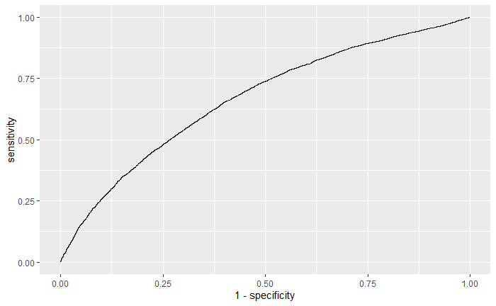

```r
model1a_pred <- model1a_data %>%
  add_predictions(model1a, type = "response")

roc_obj_model1a <- model1a_pred %>%
  roc(response = is_delayed, predictor = pred)
ggroc(roc_obj_model1a,
      legacy.axes = TRUE)
```

```r
auc(roc_obj_model1a)
```

```
Area under the curve: 0.6674
```

```r
model1a_glmulti_data <- model1a_data

# model 1a using glmulti genetic algorithm
model1a_glmulti <- glmulti(
  is_delayed ~ .,
  data = model1a_glmulti_data,
  level = 1,               # Interactions considered
  method = "h",            # Exhaustive approach
  crit = "aic",            # BIC as criteria
  confsetsize = 1,        # Keep 10 best models
  marginality = TRUE,      # consider pairs only if both main effects in model
  #minsize = 12,             # minsize, maxsize and marginality here force
  #maxsize = 12,             # inclusion of a single pair beyond the five main effects
  plotty = F,
  report = T,              # No plots, but provide interim reports
  fitfunction = "glm",     # glm function
  family = binomial(link = "logit")) # binomial family for logistic regression

summary(model1a_glmulti)

# best model: is_delayed ~ 1 + wind_speed + visib + min_wind_dev + wind_magnitude + humidity + pressure + temperature + prcp + snow + snow_depth + has_weather_warning
```

```r
model1a_glmulti_data <- model1a_data

# model 1a using glmulti genetic algorithm
model1a_glmulti_interactions <- glmulti(
  is_delayed ~ 1 + wind_speed + visib + min_wind_dev + wind_magnitude + humidity
  + pressure + temperature + prcp + snow + snow_depth + has_weather_warning,
  data = model1a_glmulti_data,
  level = 2,               # Interactions considered
  method = "h",            # Exhaustive approach
  crit = "bic",            # BIC as criteria
  confsetsize = 1,        # Keep 10 best models
  marginality = TRUE,      # consider pairs only if both main effects in model
  minsize = 12,             # minsize, maxsize and marginality here force
  #maxsize = 12,             # inclusion of a single pair beyond the five main effects
  plotty = F,
  report = T,              # No plots, but provide interim reports
  fitfunction = "glm",     # glm function
  family = binomial(link = "logit")) # binomial family for logistic regression

summary(model1a_glmulti_interactions)
```

Delay threshold >= 0: 0.6463 Delay threshold >= 10: 0.6598 Delay threshold >= 20: 0.6687

```r
model1b <- glm(is_delayed ~ .,
              data = model1b_data,
              family = binomial(link = "logit"))

summary(model1b)
```

```
Call:
glm(formula = is_delayed ~ ., family = binomial(link = "logit"),
    data = model1b_data)

Deviance Residuals:
    Min       1Q   Median       3Q      Max
-2.1616  -0.7531  -0.4889  -0.2155   2.6695

Coefficients:
                          Estimate Std. Error z value Pr(>|z|)
(Intercept)              9.8088384  1.5548866   6.308 2.82e-10 ***
wdayMon                  0.2000307  0.0364277   5.491 3.99e-08 ***
wdayTue                  0.0003219  0.0372102   0.009 0.993098
wdayWed                  0.0049482  0.0367192   0.135 0.892803
wdayThu                  0.2705851  0.0363879   7.436 1.04e-13 ***
wdayFri                  0.2384797  0.0362481   6.579 4.73e-11 ***
wdaySat                 -0.3479383  0.0414947  -8.385  < 2e-16 ***
month                   -0.0670162  0.0057156 -11.725  < 2e-16 ***
hour                     0.1754213  0.0025933  67.643  < 2e-16 ***
wind_speed               0.0383073  0.0044794   8.552  < 2e-16 ***
visib                   -0.0303123  0.0054807  -5.531 3.19e-08 ***
min_wind_dev             0.0019036  0.0013885   1.371 0.170391
wind_magnitude          -0.0005272  0.0001453  -3.627 0.000286 ***
humidity                 0.0012121  0.0006505   1.863 0.062401 .
pressure                -0.0136034  0.0015136  -8.987  < 2e-16 ***
temperature              0.0260100  0.0019044  13.658  < 2e-16 ***
prcp                     0.0144803  0.0011464  12.631  < 2e-16 ***
snow                     0.0048555  0.0010307   4.711 2.46e-06 ***
snow_depth               0.0101318  0.0004926  20.567  < 2e-16 ***
has_weather_warningTRUE  0.4077349  0.0279732  14.576  < 2e-16 ***
---
Signif. codes:  0 ‘***’ 0.001 ‘**’ 0.01 ‘*’ 0.05 ‘.’ 0.1 ‘ ’ 1

(Dispersion parameter for binomial family taken to be 1)

    Null deviance: 75124  on 66808  degrees of freedom
Residual deviance: 64865  on 66789  degrees of freedom
AIC: 64905

Number of Fisher Scoring iterations: 4
```

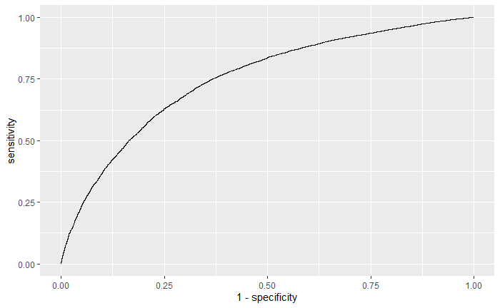

```r
model1b_pred <- model1b_data %>%
  add_predictions(model1b, type = "response")

roc_obj_model1b <- model1b_pred %>%
  roc(response = is_delayed, predictor = pred)
ggroc(roc_obj_model1b,
      legacy.axes = TRUE)
```

```r
auc(roc_obj_model1b)
```

```
Area under the curve: 0.7509
```

Delay threshold >= 0: 0.7191 Delay threshold >= 10: 0.7377 Delay threshold >= 20: 0.7495

```r
model1c <- glm(is_delayed ~ .,
              data = model1c_data,
              family = binomial(link = "logit"))

summary(model1c)
```

```
Call:
glm(formula = is_delayed ~ ., family = binomial(link = "logit"),
    data = model1c_data)

Deviance Residuals:
    Min       1Q   Median       3Q      Max
-2.1452  -0.7463  -0.4809  -0.1779   2.7298

Coefficients:
                          Estimate Std. Error z value Pr(>|z|)
(Intercept)             10.5385973  1.5662385   6.729 1.71e-11 ***
wdayMon                  0.2042599  0.0366874   5.568 2.58e-08 ***
wdayTue                  0.0023477  0.0374753   0.063 0.950047
wdayWed                  0.0040341  0.0369761   0.109 0.913124
wdayThu                  0.2749824  0.0366477   7.503 6.22e-14 ***
wdayFri                  0.2399272  0.0365063   6.572 4.96e-11 ***
wdaySat                 -0.3642685  0.0417721  -8.720  < 2e-16 ***
month                   -0.0676761  0.0057575 -11.754  < 2e-16 ***
hour                     0.1826228  0.0026690  68.425  < 2e-16 ***
carrierUA               -0.8962039  0.0382670 -23.420  < 2e-16 ***
carrierNK               -0.8963971  0.0869117 -10.314  < 2e-16 ***
carrierAA               -1.0194349  0.1461934  -6.973 3.10e-12 ***
carrierEV               -0.5440952  0.0583332  -9.327  < 2e-16 ***
carrierDL               -0.7011500  0.0611237 -11.471  < 2e-16 ***
carrierAS               -0.9266428  0.0834959 -11.098  < 2e-16 ***
carrierWN               -0.4325108  0.0531123  -8.143 3.85e-16 ***
carrierVX               -0.3058778  0.0676105  -4.524 6.06e-06 ***
carrierOO               -0.2430970  0.0950551  -2.557 0.010545 *
plane_age                0.0164417  0.0017994   9.137  < 2e-16 ***
engineTurbo-jet         -0.3097864  0.1259850  -2.459 0.013936 *
engineTurbo-shaft        0.8014349  0.3938051   2.035 0.041840 *
engineReciprocating      0.3470044  0.2148340   1.615 0.106263
engine4 Cycle           -0.2575638  0.4773885  -0.540 0.589524
engineTurbo-prop        -0.0624440  0.7065176  -0.088 0.929572
engine2 Cycle           -1.0004324  1.1456967  -0.873 0.382549
size_catsmall           -0.0806289  0.0567935  -1.420 0.155699
size_catlarge            0.3445486  0.0566905   6.078 1.22e-09 ***
wind_speed               0.0392646  0.0045102   8.706  < 2e-16 ***
visib                   -0.0309389  0.0055175  -5.607 2.05e-08 ***
min_wind_dev             0.0019010  0.0013985   1.359 0.174059
wind_magnitude          -0.0005327  0.0001463  -3.640 0.000273 ***
humidity                 0.0011505  0.0006558   1.754 0.079354 .
pressure                -0.0139844  0.0015238  -9.177  < 2e-16 ***
temperature              0.0264116  0.0019182  13.769  < 2e-16 ***
prcp                     0.0146567  0.0011536  12.706  < 2e-16 ***
snow                     0.0052254  0.0010363   5.042 4.60e-07 ***
snow_depth               0.0103077  0.0004965  20.761  < 2e-16 ***
has_weather_warningTRUE  0.4188146  0.0281916  14.856  < 2e-16 ***
---
Signif. codes:  0 ‘***’ 0.001 ‘**’ 0.01 ‘*’ 0.05 ‘.’ 0.1 ‘ ’ 1

(Dispersion parameter for binomial family taken to be 1)

    Null deviance: 75124  on 66808  degrees of freedom
Residual deviance: 64097  on 66771  degrees of freedom
AIC: 64173

Number of Fisher Scoring iterations: 5
```

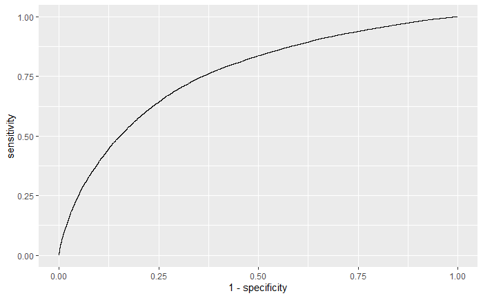

```r
model1c_pred <- model1c_data %>%
  add_predictions(model1c, type = "response")

roc_obj_model1c <- model1c_pred %>%
  roc(response = is_delayed, predictor = pred)
ggroc(roc_obj_model1c,
      legacy.axes = TRUE)
```

```r
auc(roc_obj_model1c)
```

```
Area under the curve: 0.7584
```

Delay threshold >= 0: 0.7292 Delay threshold >= 10: 0.7453 Delay threshold >= 20: 0.757

With engine: Area under the curve: 0.7292 Without engine: Area under the curve: 0.729 Without carrier: Area under the curve: 0.7214

## Analysis of Variation - Model 1c

```r
# model1c_no_manufacturer <- glm(is_delayed ~ . - manufacturer,
#                                data = model1c_data,
#                                family = binomial(link = "logit"))
#
# anova(model1c, model1c_no_manufacturer)

model1c_no_engine <- glm(is_delayed ~ . - engine,
                               data = model1c_data,
                               family = binomial(link = "logit"))

anova(model1c, model1c_no_engine)
```

```
Analysis of Deviance Table

Model 1: is_delayed ~ wday + month + hour + carrier + plane_age + engine +
    size_cat + wind_speed + visib + min_wind_dev + wind_magnitude +
    humidity + pressure + temperature + prcp + snow + snow_depth +
    has_weather_warning
Model 2: is_delayed ~ (wday + month + hour + carrier + plane_age + engine +
    size_cat + wind_speed + visib + min_wind_dev + wind_magnitude +
    humidity + pressure + temperature + prcp + snow + snow_depth +
    has_weather_warning) - engine
  Resid. Df Resid. Dev Df Deviance
1     66771      64097
2     66777      64112 -6  -14.626
```

```r
model1c_no_carrier <- glm(is_delayed ~ . - carrier,
                               data = model1c_data,
                               family = binomial(link = "logit"))

anova(model1c, model1c_no_carrier)
```

```
Analysis of Deviance Table

Model 1: is_delayed ~ wday + month + hour + carrier + plane_age + engine +
    size_cat + wind_speed + visib + min_wind_dev + wind_magnitude +
    humidity + pressure + temperature + prcp + snow + snow_depth +
    has_weather_warning
Model 2: is_delayed ~ (wday + month + hour + carrier + plane_age + engine +
    size_cat + wind_speed + visib + min_wind_dev + wind_magnitude +
    humidity + pressure + temperature + prcp + snow + snow_depth +
    has_weather_warning) - carrier
  Resid. Df Resid. Dev Df Deviance
1     66771      64097
2     66780      64766 -9  -668.54
```

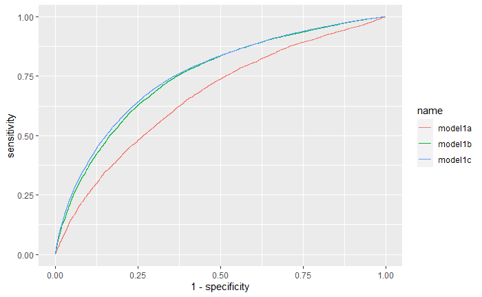

```r
ggroc(list("model1a" = roc_obj_model1a,
           "model1b" = roc_obj_model1b,
           "model1c" = roc_obj_model1c),
      legacy.axes = TRUE)
```

```r
auc(roc_obj_model1a)
```

```
Area under the curve: 0.6674
```

```r
auc(roc_obj_model1b)
```

```
Area under the curve: 0.7509
```

```r
auc(roc_obj_model1c)
```

```
Area under the curve: 0.7584
```

Delay threshold >= 0: Area under the curve: 0.6463 Area under the curve: 0.7191 Area under the curve: 0.7292

Delay threshold >= 10: Area under the curve: 0.6598 Area under the curve: 0.7377 Area under the curve: 0.7453

Delay threshold >= 20: Area under the curve: 0.6687 Area under the curve: 0.7495 Area under the curve: 0.757

# Cross-Validation

```r
library(caret)

model1_cv_data <- model1c_data %>%
  mutate(is_delayed = as.factor(if_else(is_delayed, "t", "f")),
         engine = make.names(engine)) %>%
  select(-wind_magnitude)

train_control <- trainControl(method = "repeatedcv",
                              number = 5,
                              repeats = 100,
                              savePredictions = TRUE,
                              classProbs = TRUE,
                              summaryFunction = twoClassSummary)

model <- train(is_delayed ~ . - humidity - min_wind_dev,
               data = model1_cv_data,
               trControl = train_control,
               method = "glm",
               family = binomial(link = 'logit'))

summary(model)
```

Delay threshold >= 0: 79314 Delay threshold >= 10: 70090 Delay threshold >= 20: 61797

```r
model
```

```r
model$result
```

```
Error: object 'model' not found
```

AUC Delay threshold >= 0: 0.7285887 Delay threshold >= 10: 0.7445493 Delay threshold >= 20: 0.7562068

```r
model_cv_data_pred <- test %>%
  mutate(is_delayed = as.factor(if_else(is_delayed, "t", "f")),
         engine = make.names(engine)) %>%
  add_predictions(model, var = "response") %>%
  select(is_delayed, response)

model_cv_data_pred %>%
  summarise(accuracy = sum(is_delayed == response) / n())
```

Delay_threshold >= 0: 68.6% Delay_threshold >= 10: 74.4% Delay_threshold >= 20: 78.9%

77% accuracy against test data set. (0.7699677) Adding wday, removing date: 77.1% accuracy (0.7708658)

```r
model2_base_data <- flights_planes %>%
  left_join(weather, c("time_hour", "origin")) %>%
  left_join(additional_weather, c("time_hour" = "datetime")) %>%
  left_join(daily_weather, c("date", "origin")) %>%
  drop_na() %>%
  select(-time_hour, -origin, -dest, -dep_delay, -wind_gust, -tailnum, -seats,
         -manufacturer, -date, -wind_magnitude)


model2_cv_data <- model2_base_data %>%
  mutate(is_delayed = as.factor(if_else(is_delayed, "t", "f")),
         engine = make.names(engine))

model2 <- glm(is_delayed ~ .,
              model2_base_data,
              family = binomial(link = "logit"))

summary(model2)
```

```
Call:
glm(formula = is_delayed ~ ., family = binomial(link = "logit"),
    data = model2_base_data)

Deviance Residuals:
    Min       1Q   Median       3Q      Max
-2.3735  -0.7492  -0.4859   0.5827   2.8196

Coefficients:
                          Estimate Std. Error z value Pr(>|z|)
(Intercept)              1.004e+01  1.393e+00   7.208 5.70e-13 ***
wdayMon                  2.303e-01  3.275e-02   7.031 2.05e-12 ***
wdayTue                  1.960e-02  3.358e-02   0.583 0.559573
wdayWed                  2.762e-02  3.307e-02   0.835 0.403609
wdayThu                  2.850e-01  3.278e-02   8.695  < 2e-16 ***
wdayFri                  2.448e-01  3.265e-02   7.496 6.57e-14 ***
wdaySat                 -3.425e-01  3.719e-02  -9.209  < 2e-16 ***
month                   -6.908e-02  5.118e-03 -13.497  < 2e-16 ***
hour                     1.817e-01  2.392e-03  75.950  < 2e-16 ***
carrierUA               -8.921e-01  3.408e-02 -26.176  < 2e-16 ***
carrierNK               -8.665e-01  7.695e-02 -11.261  < 2e-16 ***
carrierAA               -1.162e+00  1.340e-01  -8.670  < 2e-16 ***
carrierEV               -4.810e-01  5.237e-02  -9.185  < 2e-16 ***
carrierDL               -6.592e-01  5.436e-02 -12.127  < 2e-16 ***
carrierAS               -9.200e-01  7.486e-02 -12.289  < 2e-16 ***
carrierWN               -4.328e-01  4.727e-02  -9.157  < 2e-16 ***
carrierVX               -3.372e-01  6.051e-02  -5.572 2.52e-08 ***
carrierOO               -1.868e-01  8.490e-02  -2.200 0.027775 *
plane_age                1.619e-02  1.609e-03  10.062  < 2e-16 ***
engineTurbo-jet         -2.248e-01  1.107e-01  -2.031 0.042211 *
engineTurbo-shaft        7.508e-01  3.458e-01   2.171 0.029905 *
engineReciprocating      4.517e-01  1.920e-01   2.352 0.018667 *
engine4 Cycle           -5.363e-02  4.406e-01  -0.122 0.903118
engineTurbo-prop         2.129e-01  6.147e-01   0.346 0.729099
engine2 Cycle           -2.940e-01  8.601e-01  -0.342 0.732458
size_catsmall           -1.314e-01  5.083e-02  -2.585 0.009747 **
size_catlarge            3.479e-01  5.050e-02   6.890 5.59e-12 ***
wind_dir                 3.008e-04  8.679e-05   3.465 0.000530 ***
wind_speed               2.294e-02  2.169e-03  10.575  < 2e-16 ***
visib                   -2.975e-02  4.959e-03  -6.000 1.97e-09 ***
min_wind_dev            -2.192e-03  6.223e-04  -3.523 0.000426 ***
humidity                 1.284e-03  5.898e-04   2.177 0.029481 *
pressure                -1.342e-02  1.357e-03  -9.887  < 2e-16 ***
temperature              2.541e-02  1.709e-03  14.863  < 2e-16 ***
prcp                     1.532e-02  1.029e-03  14.887  < 2e-16 ***
snow                     4.145e-03  9.028e-04   4.591 4.42e-06 ***
snow_depth               1.035e-02  4.426e-04  23.394  < 2e-16 ***
has_weather_warningTRUE  4.411e-01  2.515e-02  17.540  < 2e-16 ***
---
Signif. codes:  0 ‘***’ 0.001 ‘**’ 0.01 ‘*’ 0.05 ‘.’ 0.1 ‘ ’ 1

(Dispersion parameter for binomial family taken to be 1)

    Null deviance: 94135  on 83510  degrees of freedom
Residual deviance: 80513  on 83473  degrees of freedom
AIC: 80589

Number of Fisher Scoring iterations: 5
```

```r
model2a <- glm(is_delayed ~ . + wind_dir:wind_speed - wind_dir,
              model2_base_data,
              family = binomial(link = "logit"))

summary(model2a)
```

```
Call:
glm(formula = is_delayed ~ . + wind_dir:wind_speed - wind_dir,
    family = binomial(link = "logit"), data = model2_base_data)

Deviance Residuals:
    Min       1Q   Median       3Q      Max
-2.3594  -0.7487  -0.4860   0.5824   2.8133

Coefficients:
                          Estimate Std. Error z value Pr(>|z|)
(Intercept)              9.894e+00  1.392e+00   7.108 1.18e-12 ***
wdayMon                  2.267e-01  3.276e-02   6.921 4.47e-12 ***
wdayTue                  2.351e-02  3.359e-02   0.700   0.4839
wdayWed                  2.648e-02  3.306e-02   0.801   0.4231
wdayThu                  2.801e-01  3.277e-02   8.550  < 2e-16 ***
wdayFri                  2.407e-01  3.266e-02   7.370 1.71e-13 ***
wdaySat                 -3.455e-01  3.719e-02  -9.290  < 2e-16 ***
month                   -6.872e-02  5.118e-03 -13.427  < 2e-16 ***
hour                     1.819e-01  2.388e-03  76.166  < 2e-16 ***
carrierUA               -8.922e-01  3.408e-02 -26.177  < 2e-16 ***
carrierNK               -8.674e-01  7.697e-02 -11.269  < 2e-16 ***
carrierAA               -1.164e+00  1.340e-01  -8.685  < 2e-16 ***
carrierEV               -4.810e-01  5.237e-02  -9.185  < 2e-16 ***
carrierDL               -6.591e-01  5.436e-02 -12.126  < 2e-16 ***
carrierAS               -9.185e-01  7.486e-02 -12.269  < 2e-16 ***
carrierWN               -4.323e-01  4.727e-02  -9.145  < 2e-16 ***
carrierVX               -3.363e-01  6.052e-02  -5.557 2.75e-08 ***
carrierOO               -1.869e-01  8.492e-02  -2.200   0.0278 *
plane_age                1.623e-02  1.610e-03  10.083  < 2e-16 ***
engineTurbo-jet         -2.253e-01  1.107e-01  -2.035   0.0418 *
engineTurbo-shaft        7.430e-01  3.461e-01   2.147   0.0318 *
engineReciprocating      4.531e-01  1.921e-01   2.359   0.0183 *
engine4 Cycle           -5.554e-02  4.407e-01  -0.126   0.8997
engineTurbo-prop         2.226e-01  6.132e-01   0.363   0.7167
engine2 Cycle           -2.932e-01  8.597e-01  -0.341   0.7331
size_catsmall           -1.309e-01  5.083e-02  -2.576   0.0100 **
size_catlarge            3.484e-01  5.050e-02   6.900 5.20e-12 ***
wind_speed               1.499e-02  2.898e-03   5.174 2.30e-07 ***
visib                   -3.050e-02  4.956e-03  -6.154 7.54e-10 ***
min_wind_dev            -2.769e-03  6.395e-04  -4.330 1.49e-05 ***
humidity                 1.466e-03  5.908e-04   2.482   0.0131 *
pressure                -1.323e-02  1.357e-03  -9.750  < 2e-16 ***
temperature              2.577e-02  1.711e-03  15.061  < 2e-16 ***
prcp                     1.560e-02  1.032e-03  15.120  < 2e-16 ***
snow                     4.311e-03  9.023e-04   4.778 1.77e-06 ***
snow_depth               1.030e-02  4.422e-04  23.297  < 2e-16 ***
has_weather_warningTRUE  4.422e-01  2.513e-02  17.596  < 2e-16 ***
wind_dir:wind_speed      4.518e-05  9.034e-06   5.001 5.71e-07 ***
---
Signif. codes:  0 ‘***’ 0.001 ‘**’ 0.01 ‘*’ 0.05 ‘.’ 0.1 ‘ ’ 1

(Dispersion parameter for binomial family taken to be 1)

    Null deviance: 94135  on 83510  degrees of freedom
Residual deviance: 80500  on 83473  degrees of freedom
AIC: 80576

Number of Fisher Scoring iterations: 5
```

```r
train_control <- trainControl(method = "repeatedcv",
                              number = 5,
                              repeats = 100,
                              savePredictions = TRUE,
                              classProbs = TRUE,
                              summaryFunction = twoClassSummary)

model <- train(is_delayed ~ . - humidity - min_wind_dev,
               data = model1_cv_data,
               trControl = train_control,
               method = "glm",
               family = binomial(link = 'logit'))

summary(model)
```

# glmulti - all data model

```r
library(GGally)

model1c_data %>%
  select(is_delayed, 1:10) %>%
  ggpairs(progress= FALSE)
```

```r
model1c_data %>%
  select(is_delayed, 11:19) %>%
  ggpairs(progress= FALSE)
```

```r
model3_glmulti_data <- model1c_data %>%
  mutate(is_delayed = as.numeric(is_delayed)) %>%
  select(-wday, -engine, -carrier)

model2_glmulti_data <- model1c_data %>%
  mutate(is_delayed = as.numeric(is_delayed))
```

```r
# model 1a using glmulti genetic algorithm
model1c_glmulti_interactions <- glmulti(
  is_delayed ~ .,
  data = model1c_glmulti_data,
  level = 2,               # Interactions considered
  method = "g",            # Exhaustive approach
  crit = "bic",            # BIC as criteria
  confsetsize = 10,        # Keep 10 best models
  marginality = TRUE,      # consider pairs only if both main effects in model
  #minsize = 18,             # minsize, maxsize and marginality here force
  #maxsize = 12,             # inclusion of a single pair beyond the five main effects
  plotty = F,
  report = T,              # No plots, but provide interim reports
  fitfunction = "glm",     # glm function
  family = binomial(link = "logit")) # binomial family for logistic regression

summary(model1c_glmulti_interactions)
```

Best model: is_delayed~1+size_cat+month+hour+plane_age+wind_speed+visib+min_wind_dev+wind_magnitude+humidity+pressure+temperature+prcp+snow+snow_depth+has_weather_warning+wind_speed:hour+wind_speed:plane_age+visib:month+wind_magnitude:wind_speed+pressure:month+pressure:hour+pressure:plane_age+pressure:humidity+temperature:month+temperature:visib+temperature:min_wind_dev+temperature:pressure+prcp:month+prcp:plane_age+prcp:min_wind_dev+prcp:wind_magnitude+prcp:pressure+prcp:temperature+snow:hour+snow:wind_speed+snow:min_wind_dev+snow:temperature+snow_depth:hour+snow_depth:pressure+snow_depth:temperature+has_weather_warning:month+has_weather_warning:hour+has_weather_warning:wind_speed+has_weather_warning:min_wind_dev+has_weather_warning:humidity+has_weather_warning:snow+has_weather_warning:snow_depth+size_cat:month+size_cat:hour+size_cat:plane_age+size_cat:has_weather_warning

# Test out best 3 models from glmulti

model1c = best model without interactions glmulti_model1 = glmulti (min 12 terms - exhaustive) glmulti_model2 = glmulti model (exhaustive) glmulti_model3 = glmulti model (genetic algorithm) - removed chr variables

```r
logregmodel1 <- glm(is_delayed ~ .,
                    data = model1c_data,
                    family = binomial(link = "logit"))

glmulti_model1 <- glm(is_delayed~1+month+hour+plane_age+wind_speed+visib+wind_magnitude+hour:month+plane_age:month+wind_speed:month+wind_speed:hour+visib:month+visib:hour+visib:plane_age+visib:wind_speed+wind_magnitude:month+wind_magnitude:hour+wind_magnitude:wind_speed+wind_magnitude:visib,
                      data = model2_glmulti_data,
                      family = binomial(link = "logit"))

glmulti_model2 <- glm(is_delayed~1+month+hour+wind_speed+visib+min_wind_dev+visib:month+visib:hour+min_wind_dev:wind_speed,
                      data = model2_glmulti_data,
                      family = binomial(link = "logit"))

glmulti_model3 <- glm(is_delayed~1+size_cat+month+hour+plane_age+wind_speed+visib+min_wind_dev+wind_magnitude+humidity+pressure+temperature+prcp+snow+snow_depth+has_weather_warning+wind_speed:hour+wind_magnitude:month+humidity:month+temperature:wind_speed+temperature:visib+temperature:pressure+prcp:month+prcp:hour+prcp:min_wind_dev+prcp:pressure+snow:hour+snow:temperature+snow_depth:humidity+snow_depth:temperature+has_weather_warning:month+has_weather_warning:hour+has_weather_warning:wind_speed+has_weather_warning:humidity+size_cat:hour,
                      data = model3_glmulti_data,
                      family = binomial(link = "logit"))
```

```r
# base model
logregmodel1_pred <- model1c_data %>%
  add_predictions(logregmodel1, type = "response")

roc_obj_logregmodel1 <- logregmodel1_pred %>%
  roc(response = is_delayed, predictor = pred)
#glmulti model 1
glmulti_model1_pred <- model2_glmulti_data %>%
  add_predictions(glmulti_model1, type = "response")

roc_obj_glmulti_model1 <- glmulti_model1_pred %>%
  roc(response = is_delayed, predictor = pred)
#glmulti model 2
glmulti_model2_pred <- model2_glmulti_data %>%
  add_predictions(glmulti_model2, type = "response")

roc_obj_glmulti_model2 <- glmulti_model2_pred %>%
  roc(response = is_delayed, predictor = pred)
#glmulti model 3
glmulti_model3_pred <- model3_glmulti_data %>%
  add_predictions(glmulti_model3, type = "response")

roc_obj_glmulti_model3 <- glmulti_model3_pred %>%
  roc(response = is_delayed, predictor = pred)
# accuracies vs test data set

true_thresh <- 0.5

logregmodel1_pred %>%
  mutate(pred = if_else(pred >= true_thresh, TRUE, FALSE)) %>%
  summarise(accuracy = sum(is_delayed == pred) / n())
```

| accuracy |
| --- |
| 0.776572 |

```r
glmulti_model1_pred %>%
  mutate(pred = if_else(pred >= true_thresh, TRUE, FALSE)) %>%
  summarise(accuracy = sum(is_delayed == pred) / n())
```

| accuracy |
| --- |
| 0.7571435 |

```r
glmulti_model2_pred %>%
  mutate(pred = if_else(pred >= true_thresh, TRUE, FALSE)) %>%
  summarise(accuracy = sum(is_delayed == pred) / n())
```

| accuracy |
| --- |
| 0.7568591 |

```r
glmulti_model3_pred %>%
  mutate(pred = if_else(pred >= true_thresh, TRUE, FALSE)) %>%
  summarise(accuracy = sum(is_delayed == pred) / n())
```

| accuracy |
| --- |
| 0.7734736 |

```r
model1c_data
```

| wday | month | hour | carrier | is_delayed | plane_age | engine | size_cat | wind_speed | visib | min_wind_dev | wind_magnitude | humidity | pressure | temperature | prcp | snow | snow_depth | has_weather_warning |
| --- | --- | --- | --- | --- | --- | --- | --- | --- | --- | --- | --- | --- | --- | --- | --- | --- | --- | --- |
| Sun | 1 | 8 | B6 | FALSE | 7 | Turbo-fan | small | 17.26170 | 10.0 | 20 | 345.2340 | 45 | 1013 | 6.28 | 0.000 | 0 | 0 | FALSE |
| Sun | 1 | 8 | EV | FALSE | 17 | Turbo-fan | small | 17.26170 | 10.0 | 20 | 345.2340 | 45 | 1013 | 6.28 | 0.000 | 0 | 0 | FALSE |
| Sun | 1 | 8 | UA | FALSE | 27 | Turbo-fan | medium | 17.26170 | 10.0 | 20 | 345.2340 | 45 | 1013 | 6.28 | 0.000 | 0 | 0 | FALSE |
| Sun | 1 | 8 | EV | FALSE | 15 | Turbo-fan | small | 17.26170 | 10.0 | 20 | 345.2340 | 45 | 1013 | 6.28 | 0.000 | 0 | 0 | FALSE |
| Sun | 1 | 8 | EV | FALSE | 15 | Turbo-fan | small | 17.26170 | 10.0 | 20 | 345.2340 | 45 | 1013 | 6.28 | 0.000 | 0 | 0 | FALSE |
| Sun | 1 | 8 | DL | FALSE | 26 | Turbo-fan | medium | 17.26170 | 10.0 | 20 | 345.2340 | 45 | 1013 | 6.28 | 0.000 | 0 | 0 | FALSE |
| Sun | 1 | 8 | UA | FALSE | 22 | Turbo-fan | medium | 17.26170 | 10.0 | 20 | 345.2340 | 45 | 1013 | 6.28 | 0.000 | 0 | 0 | FALSE |
| Sun | 1 | 8 | B6 | FALSE | 10 | Turbo-fan | small | 17.26170 | 10.0 | 20 | 345.2340 | 45 | 1013 | 6.28 | 0.000 | 0 | 0 | FALSE |
| Sun | 1 | 8 | EV | FALSE | 15 | Turbo-fan | small | 17.26170 | 10.0 | 20 | 345.2340 | 45 | 1013 | 6.28 | 0.000 | 0 | 0 | FALSE |
| Sun | 1 | 8 | UA | TRUE | 17 | Turbo-fan | large | 17.26170 | 10.0 | 20 | 345.2340 | 45 | 1013 | 6.28 | 0.000 | 0 | 0 | FALSE |

[output cut: 990 more lines]

```r
NA
NA
```

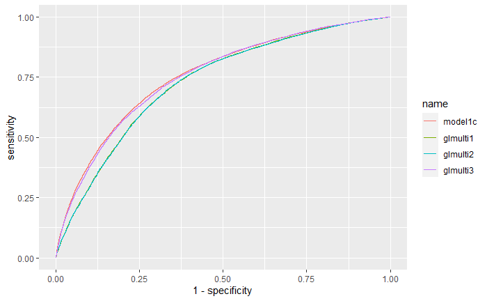

```r
ggroc(list("model1c" = roc_obj_logregmodel1,
           "glmulti1" = roc_obj_glmulti_model1,
           "glmulti2" = roc_obj_glmulti_model2,
           "glmulti3" = roc_obj_glmulti_model3),
      legacy.axes = TRUE)
```

```r
auc(roc_obj_logregmodel1)
```

```
Area under the curve: 0.7584
```

```r
auc(roc_obj_glmulti_model1)
```

```
Area under the curve: 0.7309
```

```r
auc(roc_obj_glmulti_model2)
```

```
Area under the curve: 0.7301
```

```r
auc(roc_obj_glmulti_model3)
```

```
Area under the curve: 0.755
```

```r
model_cv_data_pred %>%
  summarise(accuracy = sum(is_delayed == response) / n())
```

# Random Forest Model

| wday | month | hour | carrier | is_delayed | plane_age | engine | size_cat | wind_speed | visib | min_wind_dev | humidity | pressure | temperature | prcp | snow | snow_depth | has_weather_warning |
| --- | --- | --- | --- | --- | --- | --- | --- | --- | --- | --- | --- | --- | --- | --- | --- | --- | --- |
| Sun | 1 | 8 | B6 | FALSE | 7 | Turbo-fan | small | 17.26170 | 10.0 | 20 | 45 | 1013 | 6.28 | 0.000 | 0 | 0 | FALSE |
| Sun | 1 | 8 | EV | FALSE | 17 | Turbo-fan | small | 17.26170 | 10.0 | 20 | 45 | 1013 | 6.28 | 0.000 | 0 | 0 | FALSE |
| Sun | 1 | 8 | UA | FALSE | 27 | Turbo-fan | medium | 17.26170 | 10.0 | 20 | 45 | 1013 | 6.28 | 0.000 | 0 | 0 | FALSE |
| Sun | 1 | 8 | EV | FALSE | 15 | Turbo-fan | small | 17.26170 | 10.0 | 20 | 45 | 1013 | 6.28 | 0.000 | 0 | 0 | FALSE |
| Sun | 1 | 8 | EV | FALSE | 15 | Turbo-fan | small | 17.26170 | 10.0 | 20 | 45 | 1013 | 6.28 | 0.000 | 0 | 0 | FALSE |
| Sun | 1 | 8 | DL | FALSE | 26 | Turbo-fan | medium | 17.26170 | 10.0 | 20 | 45 | 1013 | 6.28 | 0.000 | 0 | 0 | FALSE |
| Sun | 1 | 8 | UA | FALSE | 22 | Turbo-fan | medium | 17.26170 | 10.0 | 20 | 45 | 1013 | 6.28 | 0.000 | 0 | 0 | FALSE |
| Sun | 1 | 8 | B6 | FALSE | 10 | Turbo-fan | small | 17.26170 | 10.0 | 20 | 45 | 1013 | 6.28 | 0.000 | 0 | 0 | FALSE |
| Sun | 1 | 8 | EV | FALSE | 15 | Turbo-fan | small | 17.26170 | 10.0 | 20 | 45 | 1013 | 6.28 | 0.000 | 0 | 0 | FALSE |
| Sun | 1 | 8 | UA | TRUE | 17 | Turbo-fan | large | 17.26170 | 10.0 | 20 | 45 | 1013 | 6.28 | 0.000 | 0 | 0 | FALSE |

[output cut: 990 more lines]

```r
sort(importance(rf_classifier), decreasing = TRUE)
```

```
               hour         temperature           plane_age            humidity
         2453.95238          1325.75279          1051.22926           897.23767
           pressure             carrier          wind_speed                prcp
          861.61212           672.26866           658.16376           549.29316
              month                wday        min_wind_dev               visib
          529.85737           501.61026           422.69852           296.39792
           size_cat has_weather_warning          snow_depth              engine
          271.56747           212.82646           165.03424            46.45608
               snow
           42.99747
```

| wday | month | hour | carrier | is_delayed | plane_age | engine | size_cat | wind_speed | visib | min_wind_dev | wind_magnitude | humidity | pressure | temperature | prcp | snow | snow_depth | has_weather_warning | pred |
| --- | --- | --- | --- | --- | --- | --- | --- | --- | --- | --- | --- | --- | --- | --- | --- | --- | --- | --- | --- |
| Sun | 1 | 8 | B6 | FALSE | 7 | Turbo-fan | small | 17.26170 | 10.0 | 20 | 345.2340 | 45 | 1013 | 6.28 | 0.000 | 0 | 0 | FALSE | FALSE |
| Sun | 1 | 8 | EV | FALSE | 17 | Turbo-fan | small | 17.26170 | 10.0 | 20 | 345.2340 | 45 | 1013 | 6.28 | 0.000 | 0 | 0 | FALSE | FALSE |
| Sun | 1 | 8 | UA | FALSE | 27 | Turbo-fan | medium | 17.26170 | 10.0 | 20 | 345.2340 | 45 | 1013 | 6.28 | 0.000 | 0 | 0 | FALSE | FALSE |
| Sun | 1 | 8 | EV | FALSE | 15 | Turbo-fan | small | 17.26170 | 10.0 | 20 | 345.2340 | 45 | 1013 | 6.28 | 0.000 | 0 | 0 | FALSE | FALSE |
| Sun | 1 | 8 | EV | FALSE | 15 | Turbo-fan | small | 17.26170 | 10.0 | 20 | 345.2340 | 45 | 1013 | 6.28 | 0.000 | 0 | 0 | FALSE | FALSE |
| Sun | 1 | 8 | DL | FALSE | 26 | Turbo-fan | medium | 17.26170 | 10.0 | 20 | 345.2340 | 45 | 1013 | 6.28 | 0.000 | 0 | 0 | FALSE | FALSE |
| Sun | 1 | 8 | UA | FALSE | 22 | Turbo-fan | medium | 17.26170 | 10.0 | 20 | 345.2340 | 45 | 1013 | 6.28 | 0.000 | 0 | 0 | FALSE | FALSE |
| Sun | 1 | 8 | B6 | FALSE | 10 | Turbo-fan | small | 17.26170 | 10.0 | 20 | 345.2340 | 45 | 1013 | 6.28 | 0.000 | 0 | 0 | FALSE | FALSE |
| Sun | 1 | 8 | EV | FALSE | 15 | Turbo-fan | small | 17.26170 | 10.0 | 20 | 345.2340 | 45 | 1013 | 6.28 | 0.000 | 0 | 0 | FALSE | FALSE |
| Sun | 1 | 8 | UA | TRUE | 17 | Turbo-fan | large | 17.26170 | 10.0 | 20 | 345.2340 | 45 | 1013 | 6.28 | 0.000 | 0 | 0 | FALSE | FALSE |

[output cut: 990 more lines]

```r
confusionMatrix(delays_pred$pred, delays_pred$is_delayed)
```

```
Confusion Matrix and Statistics

          Reference
Prediction FALSE  TRUE
     FALSE 48473  8976
     TRUE   1640  7720

               Accuracy : 0.8411
                 95% CI : (0.8383, 0.8439)
    No Information Rate : 0.7501
    P-Value [Acc > NIR] : < 2.2e-16

                  Kappa : 0.5034

 Mcnemar's Test P-Value : < 2.2e-16

            Sensitivity : 0.9673
            Specificity : 0.4624
         Pos Pred Value : 0.8438
         Neg Pred Value : 0.8248
             Prevalence : 0.7501
         Detection Rate : 0.7255
   Detection Prevalence : 0.8599
      Balanced Accuracy : 0.7148

       'Positive' Class : FALSE
```

```r
delays_pred_test_data <- test %>%
  mutate(is_delayed = as.factor(is_delayed)) %>%
  mutate(pred = predict(rf_classifier, data = test)$predictions)

confusionMatrix(delays_pred_test_data$pred, delays_pred_test_data$is_delayed)
```

```
Confusion Matrix and Statistics

          Reference
Prediction FALSE  TRUE
     FALSE 11655  2813
     TRUE    768  1466

               Accuracy : 0.7856
                 95% CI : (0.7793, 0.7918)
    No Information Rate : 0.7438
    P-Value [Acc > NIR] : < 2.2e-16

                  Kappa : 0.3329

 Mcnemar's Test P-Value : < 2.2e-16

            Sensitivity : 0.9382
            Specificity : 0.3426
         Pos Pred Value : 0.8056
         Neg Pred Value : 0.6562
             Prevalence : 0.7438
         Detection Rate : 0.6978
   Detection Prevalence : 0.8662
      Balanced Accuracy : 0.6404

       'Positive' Class : FALSE
```